# GoMx sperm whale habitat models: Presence/absence with GAMs

Kaitlin Frasier

Scripps Institution of Oceanography, UC San Diego

04 February 2021

# 1. Exploratory analysis

## 1.1 Data Inputs

NOAA SEFSC visual data goes back to 1992, but as shown in the figure below, many predictor variables are only available starting in 2003, therefore earlier visual data is currently excluded from further analyses.

Note: Future work could use monthly climatologies (averages) so that older sightings data could be used. Some dynamic drivers like eddy and front locations would not be able to be considered using that approach.

**Visual data predictor variable availability:**

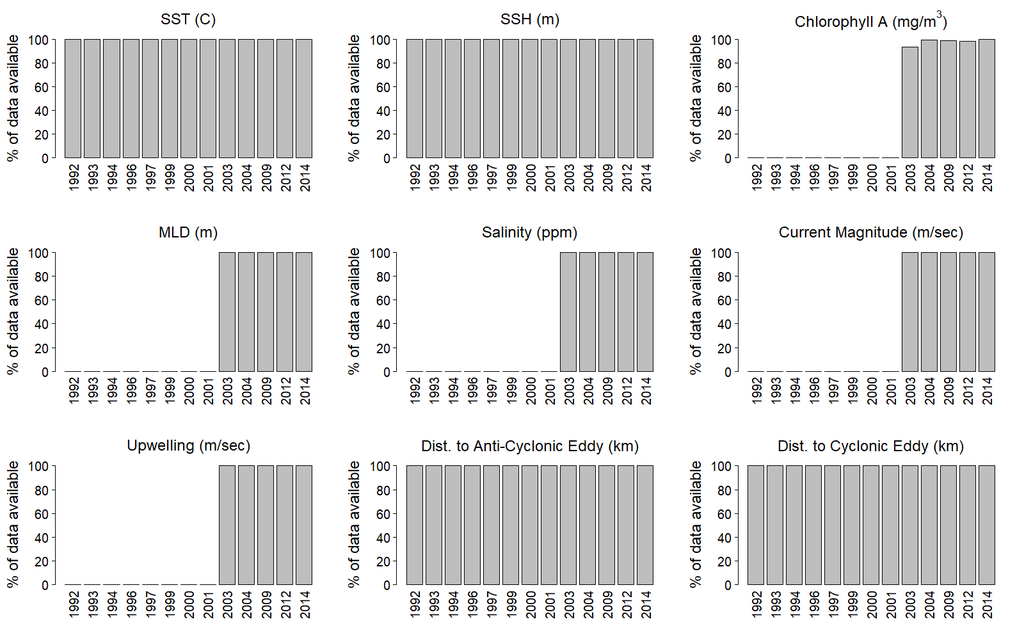

### 1.1.1 Splitting into testing and training sets

The data are split into training and testing sets. In this case, visual data from 2009 and acoustic data from 2013 were used only for testing. Only observations from 2003 or later were used for modeling due to covariate limitations.

### 1.1.2 Map of visual sightings data

The visual data selected for modeling are displayed on the map below. Data from 2009 were held back for testing. Blue markers indicate HARP locations.

[interactive chart not shown]

### 1.1.3 Time series of acoustic data

The time series below show timeseries of estimated densities from passive acoustic data used for modeling (Densities were calculated following methods detailed in [1]). Data from 2011 and 2012 were used for training, and 2013 data was held back for testing.

**Acoustic Timeseries:**

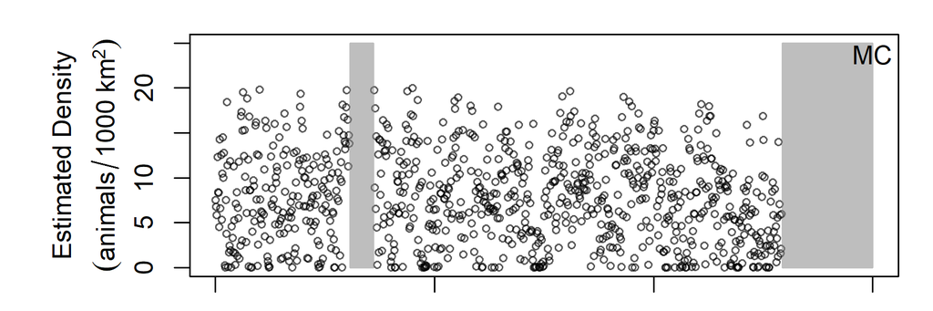

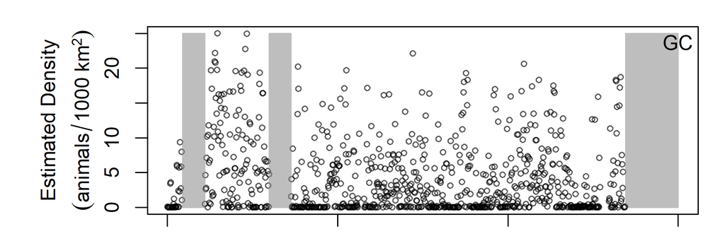

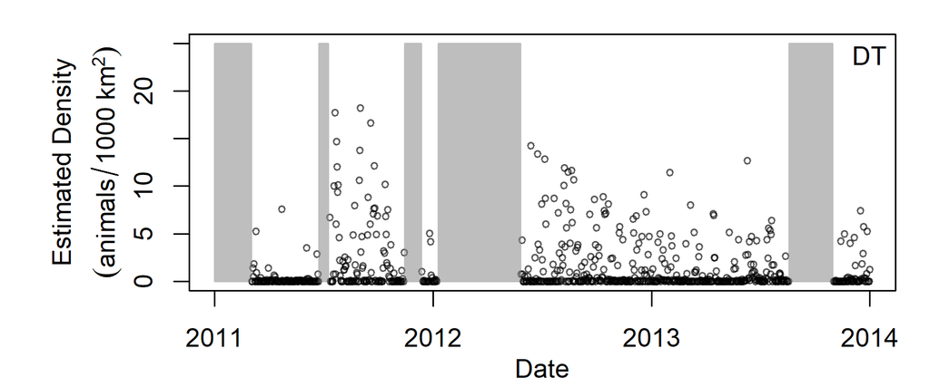

## 1.2 Examination of covariates

### 1.2.1 Covariate distribution check

**Distributions of covariates from acoustic observations (training data only):**

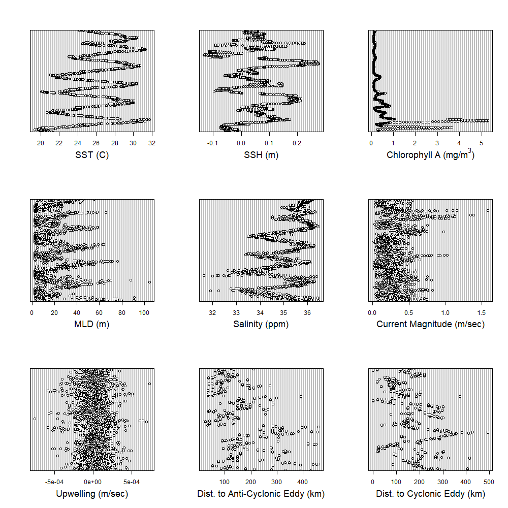

**Distributions of covariates from the visual observations (training data only):**

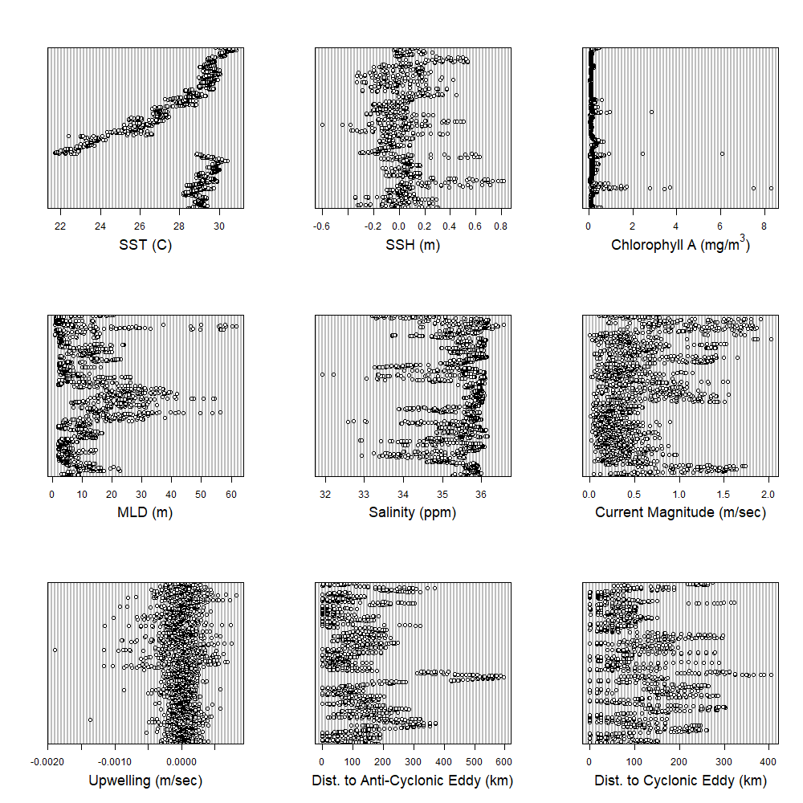

Some of these covariates are more or less interrelated. Correlations are examined in the figure below. Numbers closer to 1 above the diagonal in the figure below represent correlation coefficients. If a pair of covariates is highly-correlated only one should typically be used in the model.

**Covariate Correlations:**

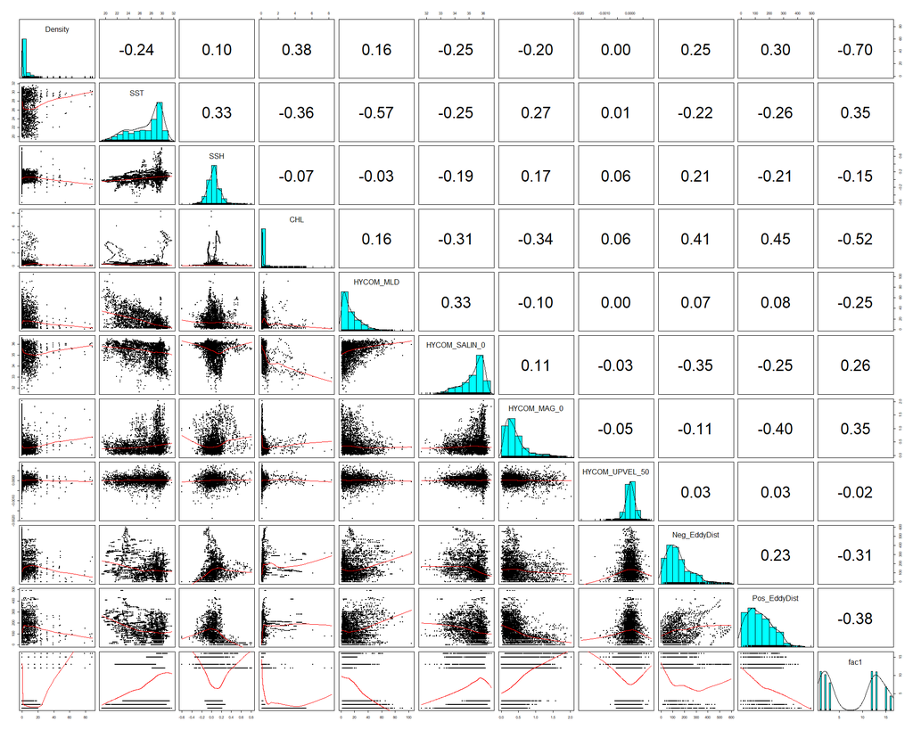

### 1.2.3 Preliminary check of predictive power

To get an idea of the basic predictive power of these covariates, we can look at presence/absence relative to each variable. This also provides an opportunity to look at the range of values observed for each covariate in the visual and acoustic datasets. In the plots below dotted lines indicate the distribution of each covariate when Sperm whale were present, and solid lines indicate the distribution when Sperm whale were absent. Note that these plots do not account for effort.

**Acoustic kernel densities:**

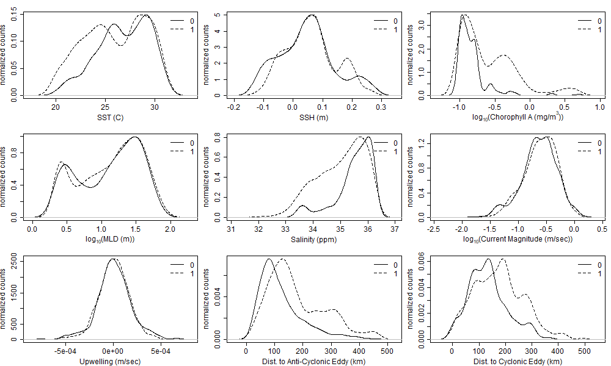

**Visual kernel densities:**

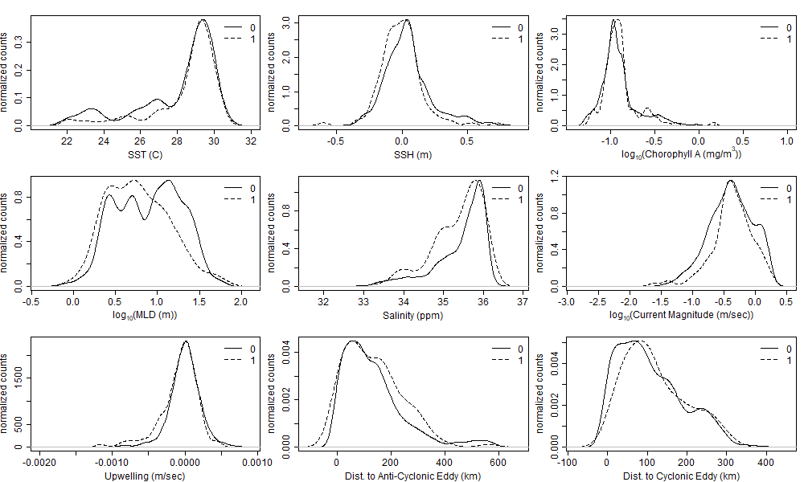

**Best visual detection probability model for Sperm whale:**

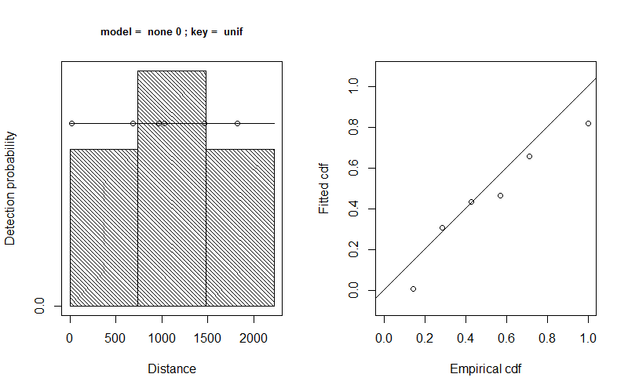

# 2. Model Fitting

Models were fit using gam from the mgcv package in R [2].

## 2.2 Run GAMs

Run GAMs on acoustic and visual datasets.

```r
varNames <- names(transformedCovars_AcOnly.train)
varNamesFormula <- varNames[2:10]
formulaAcOnly_allVars <-paste('s(', varNamesFormula, ", bs = 'ts', k = kVal)", sep = "", collapse = ' + ')
formulaAcOnly_allVars <- as.formula(paste('yAcOnly ~',formulaAcOnly_allVars))
gam_full_AcOnly <- gam(formulaAcOnly_allVars,
                               data = transformedCovars_AcOnly.train,
                               na.action = na.omit,family = tw())
```

```r
formulaVisOnly_allVars <-paste('s(', varNamesFormula, ", bs = 'ts', k = kVal)", sep = "", collapse = ' + ')
formulaVisOnly_allVars <- as.formula(paste('yVisOnly ~',formulaVisOnly_allVars))
gam_full_VisOnly <- gam(formulaVisOnly_allVars,
                               data = transformedCovars_VisOnly.train,
                               na.action = na.omit,
                               family = Tweedie(p = 1.5, link = log))
```

# 3. Model Summaries

## 3.1 Acoustic-only model

Model summary:

```
##
## Family: Tweedie(p=1.552)
## Link function: log
##
## Formula:
## yAcOnly ~ s(SST, bs = "ts", k = kVal) + s(SSH, bs = "ts", k = kVal) +
##     s(log10_CHL, bs = "ts", k = kVal) + s(HYCOM_SALIN_0, bs = "ts",
##     k = kVal) + s(log10_HYCOM_MAG_0, bs = "ts", k = kVal) + s(Neg_EddyDist,
##     bs = "ts", k = kVal)
##
## Parametric coefficients:
##             Estimate Std. Error t value Pr(>|t|)
## (Intercept)  1.43129    0.02875   49.78   <2e-16 ***
## ---
## Signif. codes:  0 '***' 0.001 '**' 0.01 '*' 0.05 '.' 0.1 ' ' 1
##
## Approximate significance of smooth terms:
##                         edf Ref.df      F  p-value
## s(SST)               1.7781      2 36.575  < 2e-16 ***
## s(SSH)               1.9015      2 24.104 1.01e-11 ***
## s(log10_CHL)         1.7720      2 15.772 2.52e-08 ***
## s(HYCOM_SALIN_0)     1.9582      2 82.779  < 2e-16 ***
## s(log10_HYCOM_MAG_0) 0.8386      2  2.293   0.0175 *
## s(Neg_EddyDist)      1.0672      2  7.220 9.67e-05 ***
## ---
## Signif. codes:  0 '***' 0.001 '**' 0.01 '*' 0.05 '.' 0.1 ' ' 1
##
## R-sq.(adj) =  0.171   Deviance explained = 16.7%
## -REML = 4705.5  Scale est. = 2.6936    n = 1789
```

Plot of residuals:

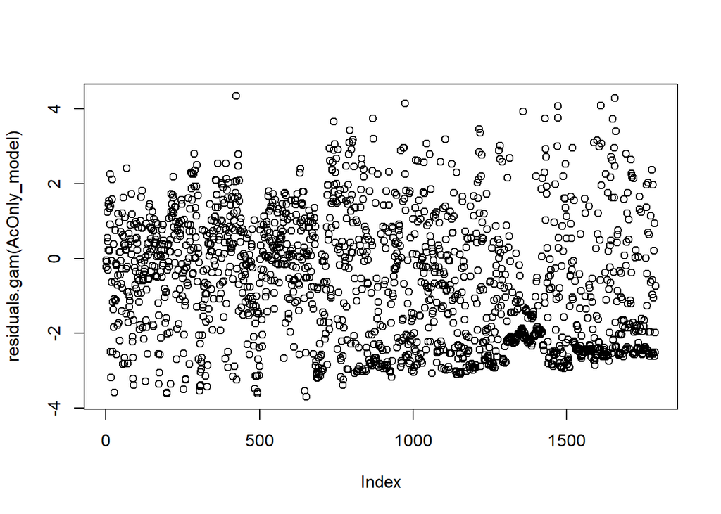